# Primer Avance

Lina Andrade - Sarai Barrios - Samuel Barona - Andres Cabezas - Samuel Álvarez

2023-10-01

```r
library(readr)
library(tidyverse)
library(dplyr)
library(xts)
library(psych)
library(gmodels)
library(MASS)
library(fitdistrplus)
library(lmtest)
library(fdth)
library(ggplot2)
library(plotly)
library(PASWR2)
library(lattice)
library(descr)
library(openxlsx)
library(kableExtra)
library(pastecs)


#Asignar directorio de trabajo
setwd('C:/Users/Family/Desktop/inferencia-estadistica-R/inferencia R')

#Comprobar directorio de trabajo
getwd()
```

```
## [1] "C:/Users/Family/Desktop/inferencia-estadistica-R/inferencia R"
```

```r
datos <-  read_csv("datos_reducidos2.csv", show_col_types = FALSE)
#view(datos)
attach(datos)

data  <- datos %>%
  filter(year >= 2018 & year <= 2020)


attach(data)
```

## **Descripción**

### **Antecedentes:**

El brote de COVID-19 afectó significativamente a la industria automotriz. Con la interrupción de la cadena de suministro y la interrupción del transporte, las nuevas incorporaciones al inventario de automóviles usados no estaban llegando al mercado. Como resultado, había menos modelos disponibles para la compra, lo que resultaba en menos compras. Sin embargo, durante las últimas etapas de 2021, el mercado comenzó a volver a la situación anterior a la pandemia, aumentando las oportunidades para el mercado de automóviles usados con un gran impulso de los consumidores de ingresos bajos y medios. A medio plazo, el mercado de automóviles usados en todo el mundo está creciendo rápidamente.

### **Planteamiento del problema:**

El aumento de las ofertas de servicios de valor agregado y la variedad de proveedores financieros que ofrecen crédito para automóviles usados contribuyen al crecimiento del mercado de automóviles usados en todo el mundo. Sin embargo, las tasas de interés son más altas, desacelerando el crecimiento de este mercado.

Factores como un aumento en los niveles de ingresos, el aumento de la demanda de automóviles de lujo, períodos de propiedad de automóviles más cortos, el auge de la importación y exportación y una creciente preferencia por los propietarios de obtener automóviles más pequeños y compactos impulsan inciden en el crecimiento del mercado.

Sin embargo, la falta de financiación o las costosas opciones de financiación en muchos países para los coches usados pueden ser un problema para el mercado. Si bien el financiamiento para autos nuevos es fácil de obtener, los autos usados atraen una tasa de interés más alta y no son sancionados tan fácilmente. Sin embargo, con el crecimiento gradual en el sector organizado, la situación del mercado está cambiando. Fabricantes, como Audi, BMW, Ford, Hyundai se han aventurado a explorar en este campo.

Es por esto que, para este informe, se creyó pertinente analizar las características presentes en este tipo de vehículos y así, poder determinar cuáles de ellos resultan una mejor opción para los compradores, pues en un mercado que parece crecer y crecer de manera exponencial, resulta abrumador tomar una decisión entre tal variedad de opciones.

### **Objetivos**

#### **Objetivo general:**

Identificar según las diferentes características de los automóviles, que marcas pueden ser la mejor opción de compra, con el fin de proporcionar una visión completa del mercado de automóviles y ayudar a la toma de decisiones informadas en la compra y venta de vehículos usados.

#### **Objetivos específicos:**

- Seleccionar los automóviles que presentan una relación óptima entre su año de fabricación y el kilometraje recorrido, con el fin de determinar el nivel de desgaste de la máquina.
- Reconocer las marcas de automóviles que ofrecen una mayor variedad de motores en su portafolio, utilizando los datos disponibles en la base de datos.
- Analizar si existe una correlación entre los precios de los automóviles y la marca, con el fin de estimar si dichos precios están influenciados por la marca.
- Evaluar si el tipo de transmisión de los automóviles influye significativamente en la variabilidad de los precios presentados en la base de datos.
- Conocer si la mayoria de vehiculos usados tiene como fuente de combustible a la gasolina.

### **Recolección de datos y análisis de resultados**

#### **Forma:**

Los datos analizados se obtuvieron de la base de datos “CARS DATASET”, que fue cargada en la plataforma web “Kaggle” en el año 2020. Esta base de datos, que sintetiza información sobre varios automóviles usados, es una versión resumida de una base de datos más extensa que consta de aproximadamente 10,000 registros y fue propuesta por Aishwarya Muthukumar. En ella, se incluye información relevante sobre el precio, la transmisión, el kilometraje, el tipo de combustible, el impuesto de circulación, las millas por galón (mpg) y el tamaño del motor de estos vehículos.

#### **Objetivo de estudio**:

#### **Población:**

La población a estudiar corresponde a los carros usados del Reino Unido presentes en la base de datos .

#### **Método de muestreo:**

Para este caso, se aplicará el método de muestreo aleatorio simple, porque permite que los elementos de la población tengan las mismas posibilidades de ser seleccionados. Teniendo en cuenta que se desea analizar las características de los carros usados para así tomar una decisión, este método de muestreo es adecuado, pues cada carro tiene igual oportunidad de ser seleccionado en la muestra, logrando una investigación objetiva y representativa, aumentando la confiabilidad en los resultados.

### **Variables de estudio:**

#### **Variables cualitativas:**

Transmisión - Escala nominal

Marca - Escala nominal

Tipo de combustible - Escala nominal

#### **Variables cuantitativas:**

#### **Discretas:**

Kilometraje (millas) - Escala de razón

#### **Continuas:**

Precio - Escala de razón.

Tamaño del motor - Escala de razón.

### **Análisis de resultados**

#### **Variables cualitativas:**

**Transmisión:** hace referencia a una variable cualitativa medida en escala nomina. A continuación, se presenta la tabla de frecuencias y la gráfica de barras:

```r
tablaTransmision = data %>% group_by(transmission) %>%
  summarize(frec_abs=n()) %>%
  mutate(frec_rel=frec_abs/sum(frec_abs)*100)

tablaTransmision
```

```
## # A tibble: 3 × 3
##   transmission frec_abs frec_rel
##   <chr>           <int>    <dbl>
## 1 Automatic         498     21.5
## 2 Manual           1185     51.2
## 3 Semi-Auto         632     27.3
```

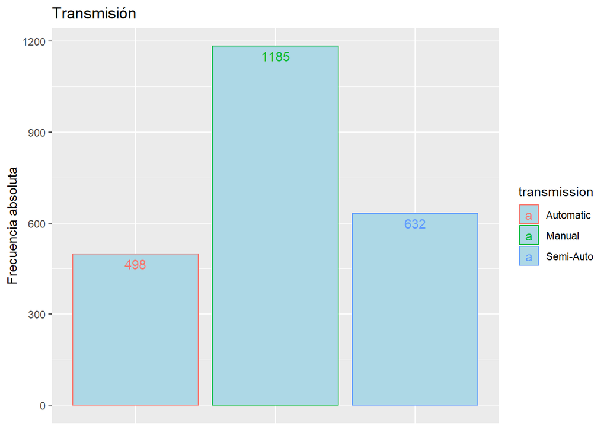

```r
ggplot(tablaTransmision, aes(x=transmission, y=frec_abs, label=paste0(frec_abs),color=transmission)) +
  geom_bar(stat='identity', fill='lightblue') +
  geom_text(vjust=1.5) +
  labs(x='Transmisión', y='Frecuencia absoluta', title='Transmisión') +
  theme(axis.title.x=element_blank(),
        axis.text.x=element_blank(),
        axis.ticks.x=element_blank())
```

**Marca:** La marca del automóvil es una variable cualitativa medida en escala nominal. A continuación, se presenta la tabla de frecuencias y la gráfica de barras asociada :

```r
tablaMarca = data %>% group_by(Make) %>%
  summarize(frec_abs=n()) %>%
  mutate(frec_rel=frec_abs/sum(frec_abs)*100)

tablaMarca
```

```
## # A tibble: 7 × 3
##   Make    frec_abs frec_rel
##   <chr>      <int>    <dbl>
## 1 BMW          371    16.0
## 2 Ford         569    24.6
## 3 Hyundai      148     6.39
## 4 audi         332    14.3
## 5 skoda        211     9.11
## 6 toyota       154     6.65
## 7 vw           530    22.9
```

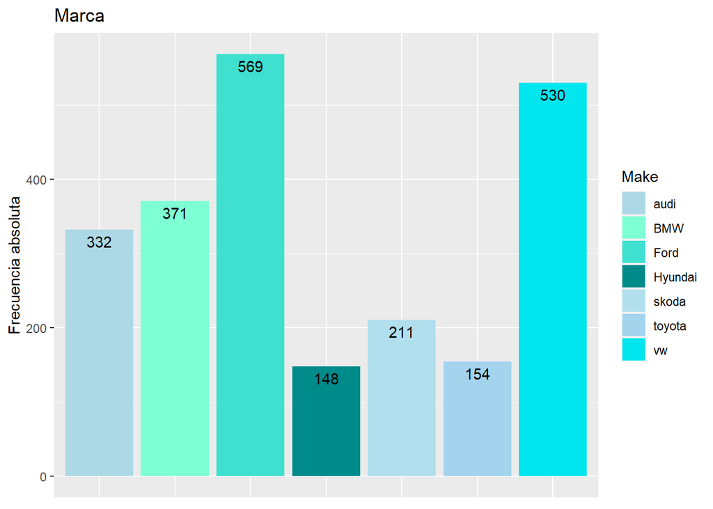

```r
colores_personalizados <- c("BMW" = "aquamarine", "Ford" = "turquoise", "Hyundai" = "cyan4",
                            "audi" = "lightblue", "skoda" = "lightblue2", "toyota" = "lightskyblue2",
                            "vw" = "turquoise2")


ggplot(tablaMarca, aes(x = Make, y = frec_abs, fill = Make)) +
  geom_bar(stat = 'identity') +
  geom_text(aes(label = frec_abs), vjust = 1.5) +
  labs(x = 'Marca', y = 'Frecuencia absoluta', title = 'Marca') +
  scale_fill_manual(values = colores_personalizados) +
  theme(axis.title.x = element_blank(),
        axis.text.x = element_blank(),
        axis.ticks.x = element_blank())
```

En cuanto a la marca, existe un poco más de diversidad en este ámbito, sin embargo, las marcas predominantes son: Ford y vw. Es decir que, en Reino Unido, la mayor cantidad de carros usados puestos en venta pertenecen a las marcas anteriormente mencionadas.

**Tipo de combustible:** El tipo de combustible es una variable cualitativa medida en escala nominal. A continuación, se presenta la tabla de frecuencias y la gráfica de barras:

```r
tablaCombustible = data %>% group_by(fuelType) %>%
  summarize(frec_abs=n()) %>%
  mutate(frec_rel=frec_abs/sum(frec_abs)*100)

tablaCombustible
```

```
## # A tibble: 4 × 3
##   fuelType frec_abs frec_rel
##   <chr>       <int>    <dbl>
## 1 Diesel        793   34.3
## 2 Hybrid         81    3.50
## 3 Other           6    0.259
## 4 Petrol       1435   62.0
```

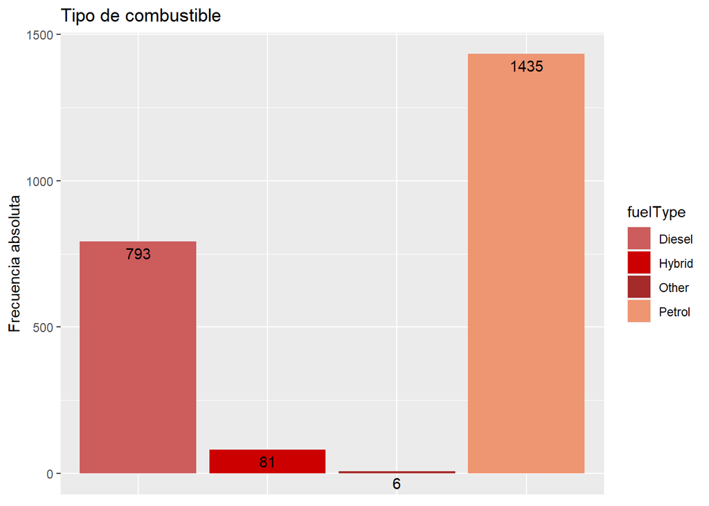

```r
colores_personalizados <- c("Diesel" = "indianred", "Electric" = "orange2", "Hybrid" = "red3", "Other" = "brown", "Petrol" = "lightsalmon2")


ggplot(tablaCombustible, aes(x = fuelType, y = frec_abs, fill = fuelType)) +
  geom_bar(stat = 'identity') +
  geom_text(aes(label = frec_abs), vjust = 1.5) +
  labs(x = 'Tipo de combustible', y = 'Frecuencia absoluta', title = 'Tipo de combustible') +
  scale_fill_manual(values = colores_personalizados) +
  theme(axis.title.x = element_blank(),
        axis.text.x = element_blank(),
        axis.ticks.x = element_blank())
```

En cuanto al diesel y la gasolina, que son los más comunes, existen variaciones de precio, que obligan al propietario a escoger entre uno u otro según presupuesto y demás consideraciones, tales como el lugar por el cual se moviliza, es decir, la gasolina es una mejor opción en las cuidades, pues es menos dañino para las personas, sin embargo, más dañino para el medio ambiente. Caso contrario con el diesel, pues es menos contaminante para el ambiente, por lo que, si se recorren rutas largas, el diesel puede ser una mejor opción.

**Precio:**

En este caso, al tratarse de una base de datos del Reino Unido, su moneda es la libra esterlina, por lo cual es importante recordar que esa será la moneda trabajada en este caso, para el precio. A continución se presenta el análisis exploratorio de los datos:

**Histograma**

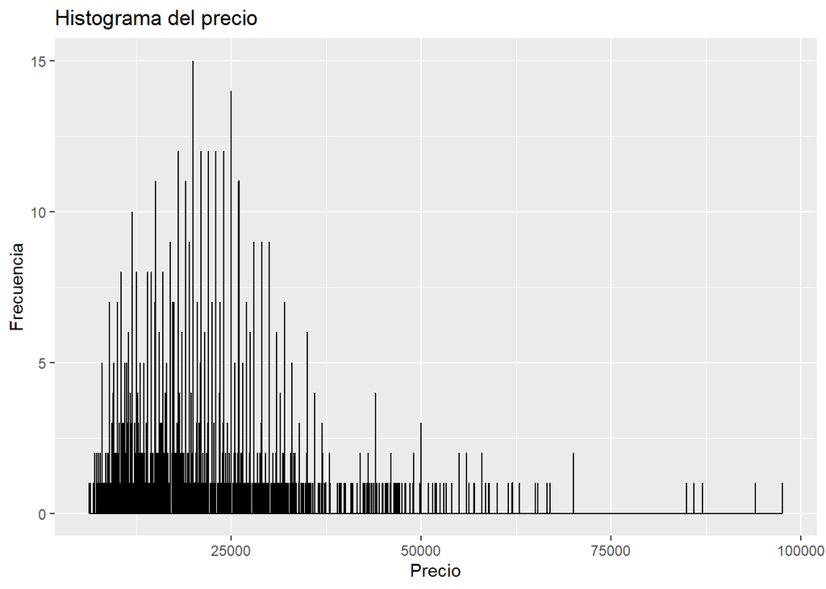

```r
ggplot(data, aes(x = price)) +
  geom_histogram(binwidth = 0.5, fill = "blue", color = "black") +
  labs(title = "Histograma del precio", x = "Precio", y = "Frecuencia")
```

**Diagrama de densidad**

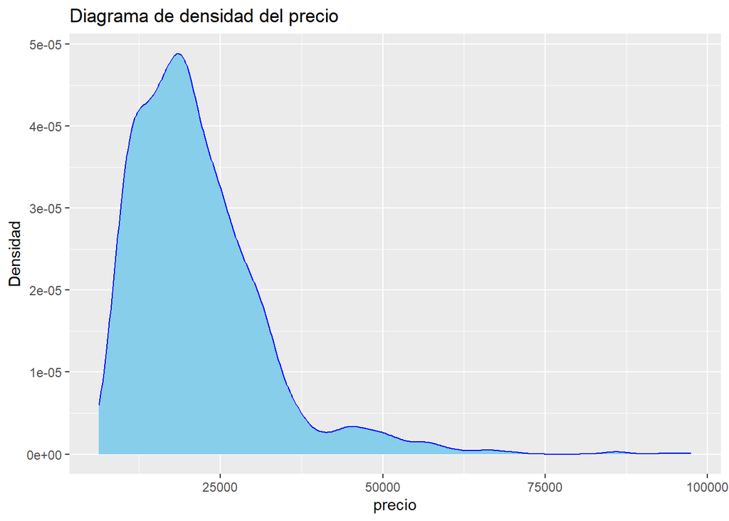

```r
ggplot(data, aes(x = price)) +
  geom_density(fill = "skyblue", color = "blue") +
  labs(title = "Diagrama de densidad del precio", x = "precio", y = "Densidad")
```

**Diagrama de cajas**:

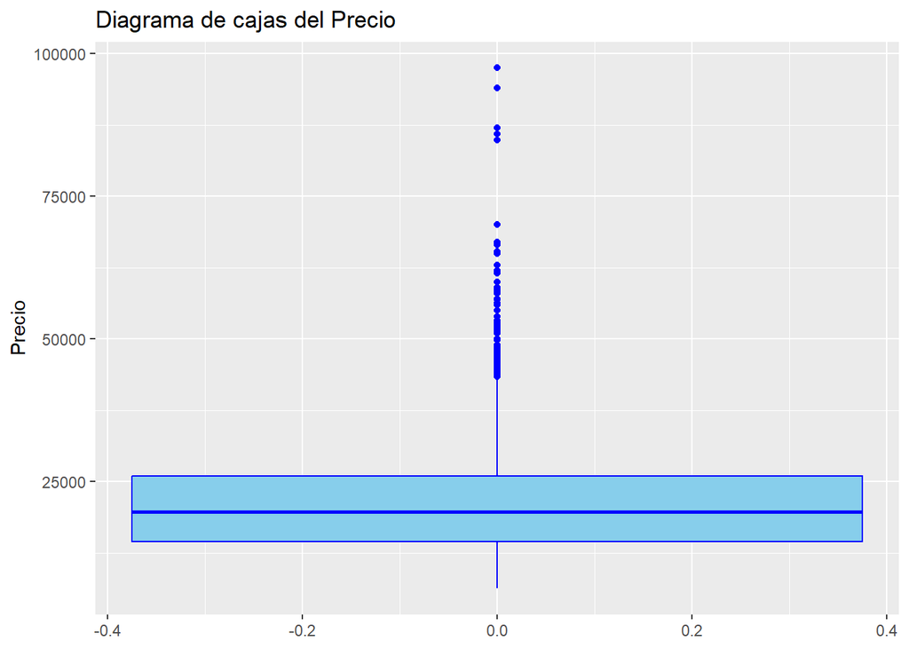

```r
ggplot(data, aes(y = price)) +
  geom_boxplot(fill = "skyblue", color = "blue") +
  labs(title = "Diagrama de cajas del Precio", y = "Precio")
```

Como se observa en el gráfico, la variable “precio” presenta varios datos atipicos, esto dado que, los precios de los automóviles son variables y dependen de distintos factores, por lo cual, para este caso, es normal encontrar tantos datos atípicos, sin embargo, más adelante se realizará la corrección.

**Q-Q plot:** Permite verificar si los datos se ajustan a una distribución teórica. Cuando los puntos del gráfico siguen de cerca la línea diagonal, se sugiere que los datos son consistentes con la distribución teórica. Las desviaciones notables de la línea diagonal pueden ser indicadores de que los datos no siguen la distribución.

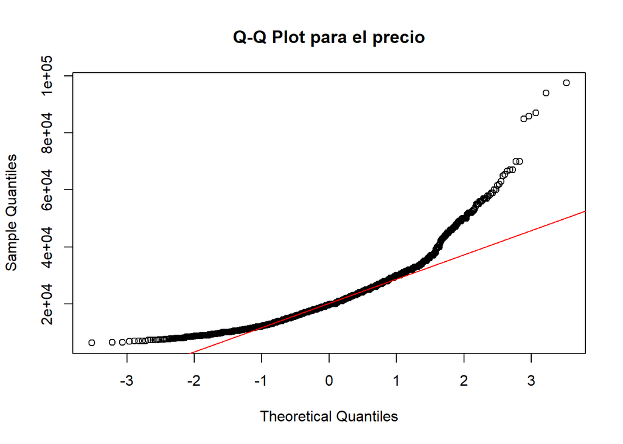

```r
qqnorm(data$price, main = "Q-Q Plot para el precio")
qqline(data$price, col = "red")
```

**Estadística descriptiva: precio**

```r
# max  y min

  min <- min(price)
  max <- max(price)

# Rango intercuartil

  rango <- max-min

#Media

  media <- mean(price)
  print(paste("Media", media))
```

```
## [1] "Media 21522.0669546436"
```

```r
#Mediana

   mediana <- median(price)
   print(paste("Mediana", mediana))
```

```
## [1] "Mediana 19699"
```

```r
#Desviación estándar

  desv_estandar <- sd(price)
  print(paste("desviación estándar" , desv_estandar))
```

```
## [1] "desviación estándar 10283.7452251986"
```

```r
#Coeficiente de variación

  coef_var <- (desv_estandar/media)*100
  print(paste("Coeficiente de variación" , coef_var))
```

```
## [1] "Coeficiente de variación 47.7823307903971"
```

```r
#Simetria

 coeficiente_simetria <- skew(data$price)
  print(paste("Coeficiente de simetría" , coeficiente_simetria))
```

```
## [1] "Coeficiente de simetría 1.82538352474832"
```

```r
#Cuartil 1

  q1 <- unname(quantile(price, 0.25))
  print(paste("cuartil 1" ,q1))
```

```
## [1] "cuartil 1 14492.5"
```

```r
#Cuartil 3
  q3 <- unname(quantile(price, 0.75))
  print(paste("Cuartil 3" , q3))
```

```
## [1] "Cuartil 3 25995"
```

```r
#Rango intercuartil
  ric <- q3 - q1
  print(paste("Rango intercuartil" , ric))
```

```
## [1] "Rango intercuartil 11502.5"
```

```r
#Cerco inferior
  cerco_inf <- q1 - 1.5*ric
  print(paste("Cerco inferior",cerco_inf))
```

```
## [1] "Cerco inferior -2761.25"
```

```r
#Cerco superior
  cerco_sup <- q3 + 1.5*ric
  print(paste("Cerco superior" , cerco_sup))
```

```
## [1] "Cerco superior 43248.75"
```

```r
  atipicos <- filter(data, price<cerco_inf | price>cerco_sup)


  datos_sinatipicos <- filter(data,price>=cerco_inf & price<=cerco_sup)

  max <- max(datos_sinatipicos$`price`)
  max
```

```
## [1] 43194
```

```r
  summary(datos_sinatipicos$price)
```

```
##    Min. 1st Qu.  Median    Mean 3rd Qu.    Max.
##    6295   13999   19102   20038   24995   43194
```

```r
  descriptivas <- stat.desc(datos_sinatipicos$price)
  descriptivas
```

```
##      nbr.val     nbr.null       nbr.na          min          max        range
## 2.212000e+03 0.000000e+00 0.000000e+00 6.295000e+03 4.319400e+04 3.689900e+04
##          sum       median         mean      SE.mean CI.mean.0.95          var
## 4.432314e+07 1.910150e+04 2.003759e+04 1.591421e+02 3.120836e+02 5.602156e+07
##      std.dev     coef.var
## 7.484755e+03 3.735358e-01
```

```r
  options(scipen = 999999)
```

Según el coeficiente de simetria, los datos son asimetricos, por lo que, se usa la mediana para representar los datos. Además, con el coeficiente de variación nos indica que se trata de datos heterogeneos.

**Tamaño del motor:**

El tamaño del motor de un automóvil se refiere al volumen total de los cilindros en el motor y se mide comúnmente en litros (L) o centímetros cúbicos (cc). A demás de que el tamaño del motor es uno aspectos que determinan el rendimiento y la eficiencia de un automóvil. A continución se presenta el análisis exploratorio de los datos:

**Histograma :**

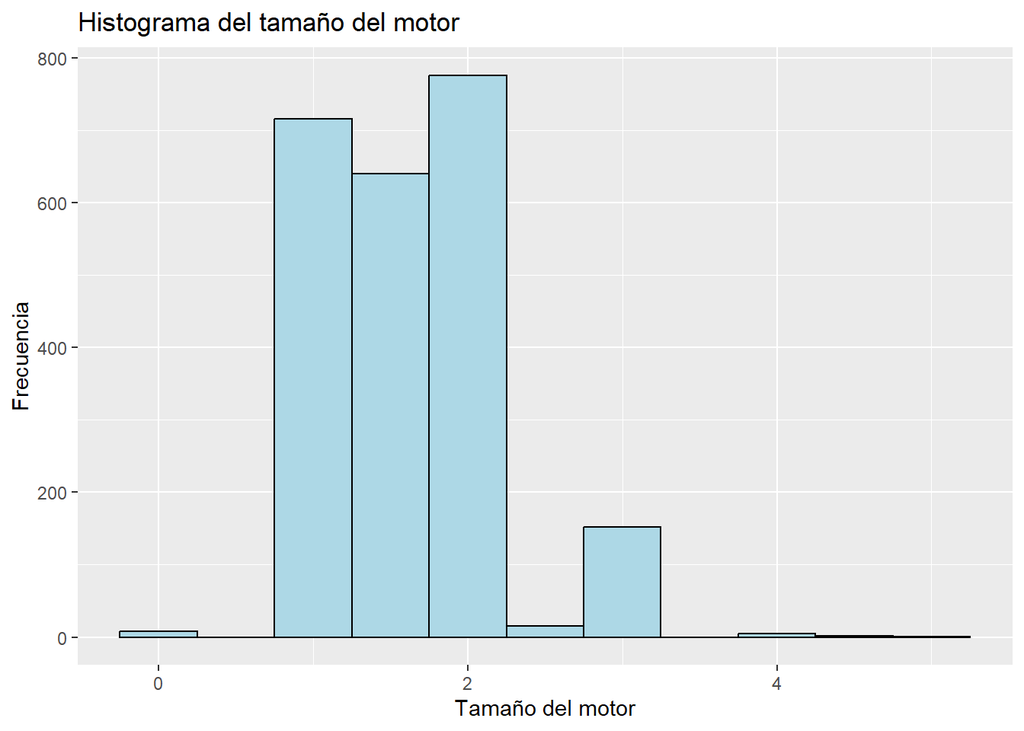

```r
ggplot(data, aes(x = engineSize)) +
  geom_histogram(binwidth = 0.5, fill = "lightblue", color = "black") +
  labs(title = "Histograma del tamaño del motor", x = "Tamaño del motor", y = "Frecuencia")
```

En este caso, la mayoria de motores oscilan en un tamaño entre 1 y 2 litros o cc, siendomotores de tamaño moderado o mediano.

Los motores con desplazamientos entre 1 y 2 litros son comunes en una amplia variedad de vehículos, desde automóviles compactos hasta automóviles medianos y algunos vehículos deportivos y utilitarios. Estos motores son adecuados para una conducción diaria y suelen ofrecer un equilibrio razonable entre potencia y eficiencia de combustible.

**Diagrama de densidad**

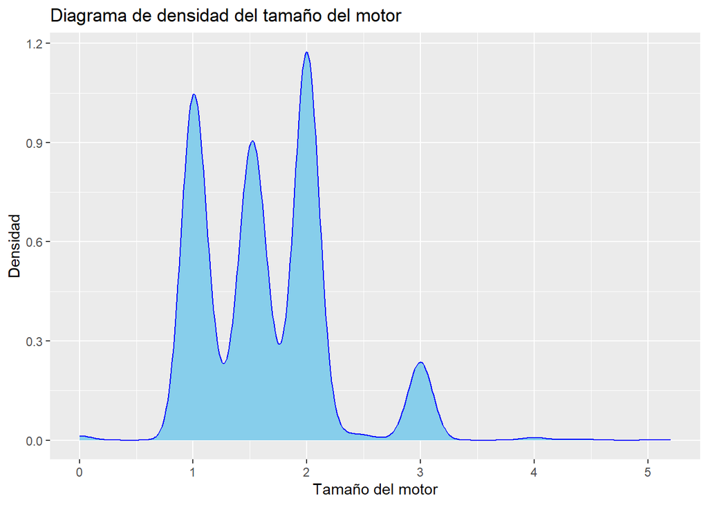

```r
ggplot(data, aes(x = engineSize)) +

  geom_density(fill = "skyblue", color = "blue") +
  labs(title = "Diagrama de densidad del tamaño del motor", x = "Tamaño del motor", y = "Densidad")
```

**Diagrama de cajas:**

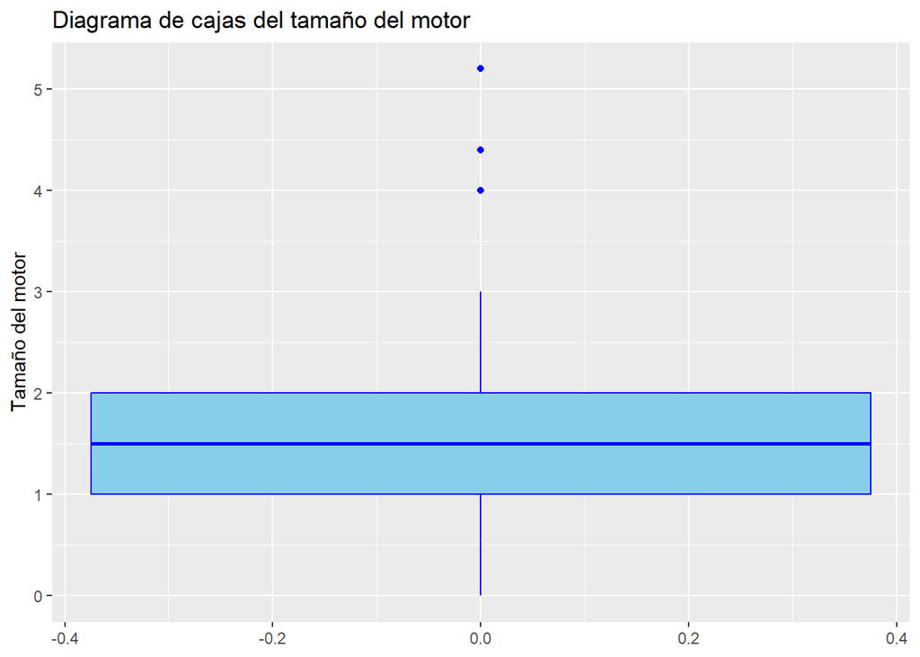

```r
ggplot(data, aes(y = engineSize)) +
  geom_boxplot(fill = "skyblue", color = "blue") +
  labs(title = "Diagrama de cajas del tamaño del motor", y = "Tamaño del motor")
```

Como se habia observado en el histograma, el tamaño del motor se encontraba entre uno y dos, por lo que, en este caso, aunque se presentan datos atipicos, no se presentan tantos como con la variable del precio.

**Q-Q plot:**

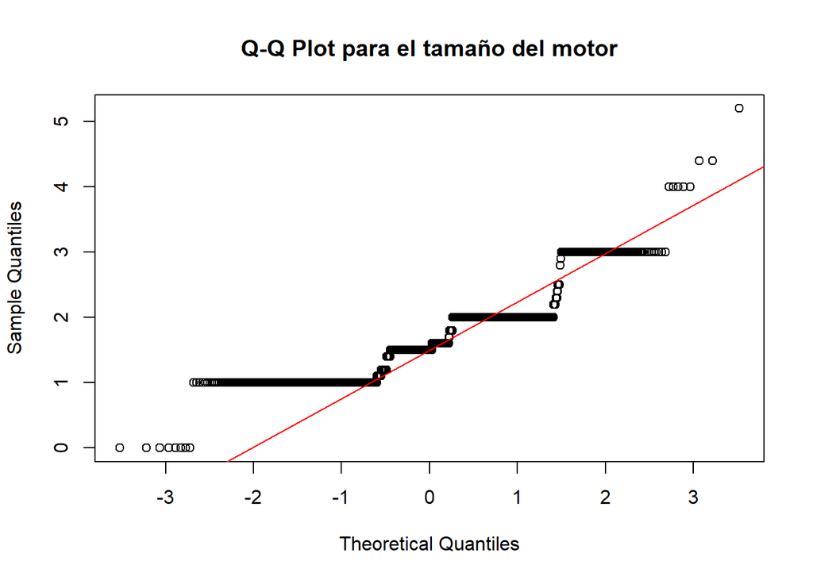

```r
qqnorm(data$engineSize, main = "Q-Q Plot para el tamaño del motor")
qqline(data$engineSize, col = "red")
```

**Estadística descriptiva: Tamaño del motor**

```r
# max  y min

  min <- min(engineSize)
  max <- max(engineSize)

# Rango intercuartil

  rango <- max-min

#Media

  media <- mean(engineSize)
  print(paste("Media", media))
```

```
## [1] "Media 1.6317494600432"
```

```r
# Mediana

  mediana <- median(engineSize)
   print(paste("Mediana", mediana))
```

```
## [1] "Mediana 1.5"
```

```r
#Desviación estándar

  desv_estandar <- sd(engineSize)
  print(paste("desviación estándar" , desv_estandar))
```

```
## [1] "desviación estándar 0.570741687423192"
```

```r
#Coeficiente de variación

  coef_var <- (desv_estandar/media)*100
  print(paste("Coeficiente de variación" , coef_var))
```

```
## [1] "Coeficiente de variación 34.9772867342076"
```

```r
#Simetria

 coeficiente_simetria <- skew(data$engineSize)
  print(paste("Coeficiente de simetría" , coeficiente_simetria))
```

```
## [1] "Coeficiente de simetría 0.887878977408621"
```

```r
#Cuartil 1

  q1 <- unname(quantile(engineSize, 0.25))
  print(paste("cuartil 1" ,q1))
```

```
## [1] "cuartil 1 1"
```

```r
#Cuartil 3
  q3 <- unname(quantile(engineSize, 0.75))
  print(paste("Cuartil 3" , q3))
```

```
## [1] "Cuartil 3 2"
```

```r
#Rango intercuartil
  ric <- q3 - q1
  print(paste("Rango intercuartil" , ric))
```

```
## [1] "Rango intercuartil 1"
```

```r
#Cerco inferior
  cerco_inf <- q1 - 1.5*ric
  print(paste("Cerco inferior",cerco_inf))
```

```
## [1] "Cerco inferior -0.5"
```

```r
#Cerco superior
  cerco_sup <- q3 + 1.5*ric
  print(paste("Cerco superior" , cerco_sup))
```

```
## [1] "Cerco superior 3.5"
```

```r
   #Evaluar cercos
  atipicos <- filter(data, engineSize<cerco_inf | engineSize>cerco_sup)


  datos_sinatipicos3 <- filter(data,engineSize>=cerco_inf & engineSize<=cerco_sup)

  max <- max(datos_sinatipicos3$`engineSize`)
  max
```

```
## [1] 3
```

```r
  summary(datos_sinatipicos3$engineSize)
```

```
##    Min. 1st Qu.  Median    Mean 3rd Qu.    Max.
##   0.000   1.000   1.500   1.623   2.000   3.000
```

```r
  descriptivas3 <- stat.desc(datos_sinatipicos3$engineSize)
  descriptivas3
```

```
##       nbr.val      nbr.null        nbr.na           min           max
## 2307.00000000    8.00000000    0.00000000    0.00000000    3.00000000
##         range           sum        median          mean       SE.mean
##    3.00000000 3743.50000000    1.50000000    1.62267013    0.01145022
##  CI.mean.0.95           var       std.dev      coef.var
##    0.02245380    0.30246503    0.54996821    0.33892791
```

```r
  options(scipen = 999999)
```

En este caso, los datos también son datos heterogeneos.

**Kilometraje:**

El kilometraje en un carro usado es un indicador que puede proporcionar información sobre el historial y la condición general del vehículo. Un bajo kilometraje es un buen indicador, pero no es el único factor que determina la calidad y el valor de un carro usado. A continución se presenta el análisis exploratorio de los datos:

**Histograma:**

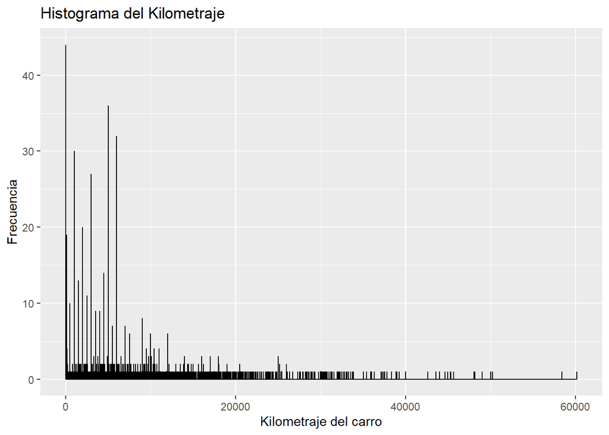

```r
mielage <- data.frame(data$mileage)
ggplot(mielage, aes(x = mileage)) +
  geom_histogram(binwidth = 0.5, fill = "lightblue", color = "black") +
  labs(title = "Histograma del Kilometraje", x = "Kilometraje del carro", y = "Frecuencia")
```

**Diagrama de densidad:**

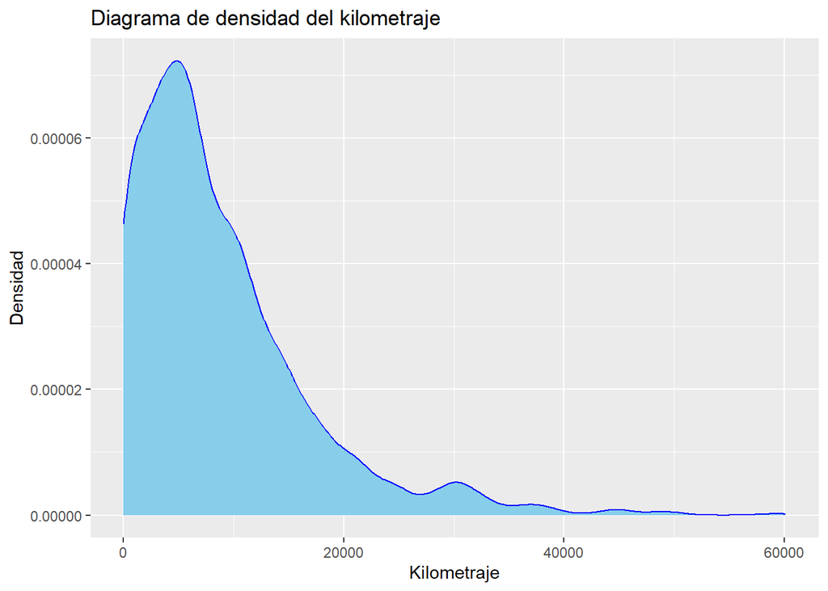

```r
ggplot(data, aes(x = mileage)) +

  geom_density(fill = "skyblue", color = "blue") +
  labs(title = "Diagrama de densidad del kilometraje", x = "Kilometraje", y = "Densidad")
```

**Diagrama de cajas:**

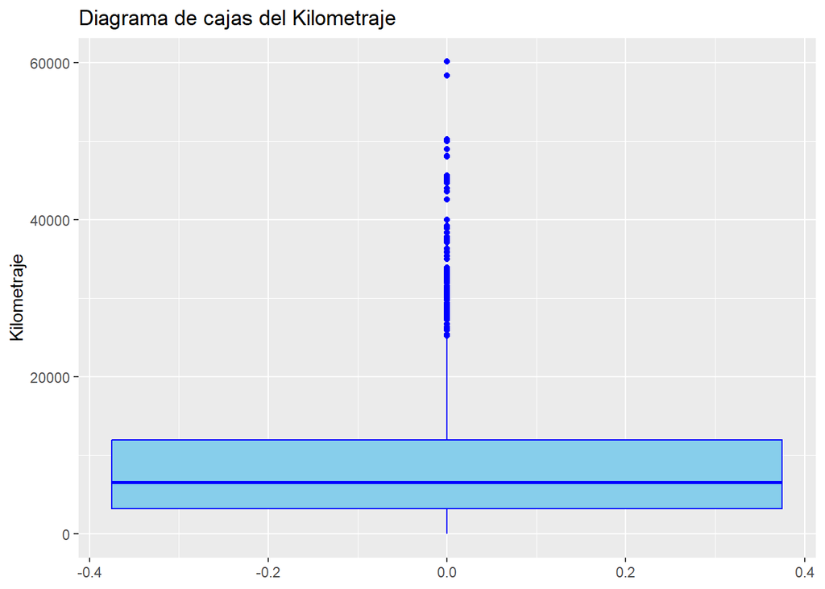

```r
ggplot(data, aes(y = mileage)) +
  geom_boxplot(fill = "skyblue", color = "blue") +
  labs(title = "Diagrama de cajas del Kilometraje", y = "Kilometraje")
```

**Q-Q plot:**

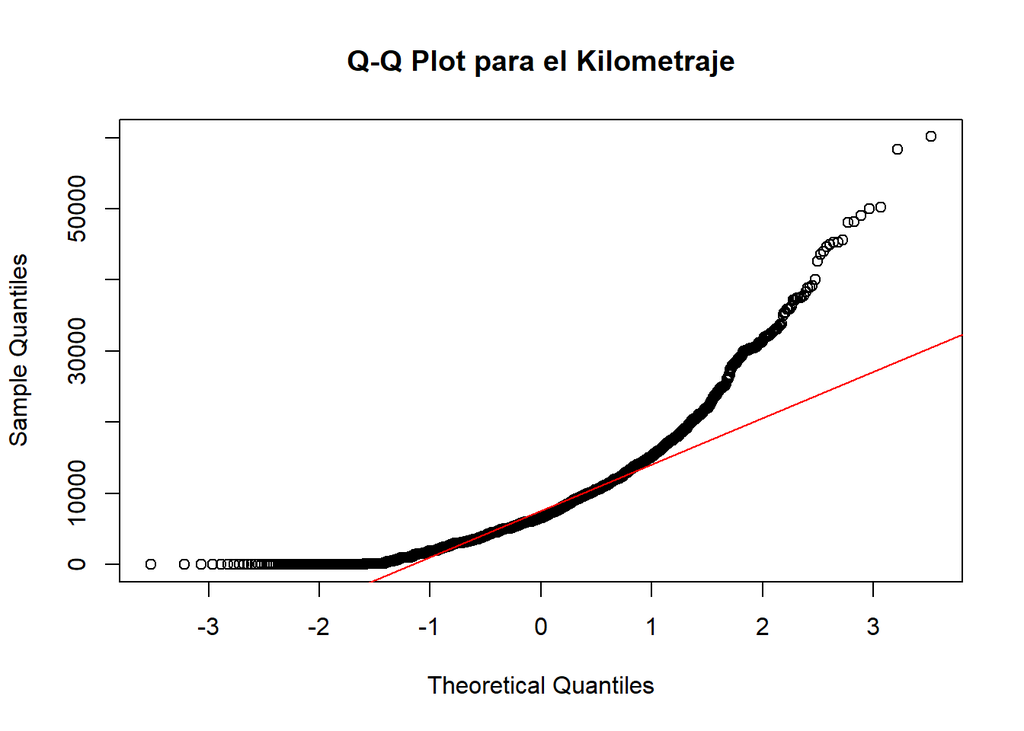

```r
qqnorm(data$mileage, main = "Q-Q Plot para el Kilometraje")
qqline(data$mileage, col = "red")
```

**Estadística descriptiva:**

```r
# max  y min

  min <- min(mileage)
  max <- max(mileage)

# Rango intercuartil

  rango <- max-min

#Media

  media <- mean(mileage)
  print(paste("Media", media))
```

```
## [1] "Media 8802.38920086393"
```

```r
# Mediana

  mediana <- median(mileage)
   print(paste("Mediana", mediana))
```

```
## [1] "Mediana 6564"
```

```r
#Desviación estándar

  desv_estandar <- sd(mileage)
  print(paste("desviación estándar" , desv_estandar))
```

```
## [1] "desviación estándar 8079.78506239002"
```

```r
#Coeficiente de variación

  coef_var <- (desv_estandar/media)*100
  print(paste("Coeficiente de variación" , coef_var))
```

```
## [1] "Coeficiente de variación 91.7908181292076"
```

```r
#Simetria

 coeficiente_simetria <- skew(data$mileage)
  print(paste("Coeficiente de simetría" , coeficiente_simetria))
```

```
## [1] "Coeficiente de simetría 1.80429045044126"
```

```r
#Cuartil 1

  q1 <- unname(quantile(mileage, 0.25))
  print(paste("cuartil 1" ,q1))
```

```
## [1] "cuartil 1 3208"
```

```r
#Cuartil 3
  q3 <- unname(quantile(mileage, 0.75))
  print(paste("Cuartil 3" , q3))
```

```
## [1] "Cuartil 3 12000"
```

```r
#Rango intercuartil
  ric <- q3 - q1
  print(paste("Rango intercuartil" , ric))
```

```
## [1] "Rango intercuartil 8792"
```

```r
#Cerco inferior
  cerco_inf <- q1 - 1.5*ric
  print(paste("Cerco inferior",cerco_inf))
```

```
## [1] "Cerco inferior -9980"
```

```r
#Cerco superior
  cerco_sup <- q3 + 1.5*ric
  print(paste("Cerco superior" , cerco_sup))
```

```
## [1] "Cerco superior 25188"
```

```r
   #Evaluar cercos
  atipicos <- filter(data, mileage<cerco_inf |mileage>cerco_sup)


  datos_sinatipicos2 <- filter(data,mileage>=cerco_inf & mileage<=cerco_sup)

  max <- max(datos_sinatipicos3$`mileage`)
  max
```

```
## [1] 60130
```

```r
  summary(datos_sinatipicos3$mileage)
```

```
##    Min. 1st Qu.  Median    Mean 3rd Qu.    Max.
##       1    3202    6584    8809   12000   60130
```

```r
  descriptivas2 <- stat.desc(datos_sinatipicos2$mileage)
  descriptivas3-2
```

[output not shown]

```r
  options(scipen = 999999)
```

**Tablas cruzadas:**

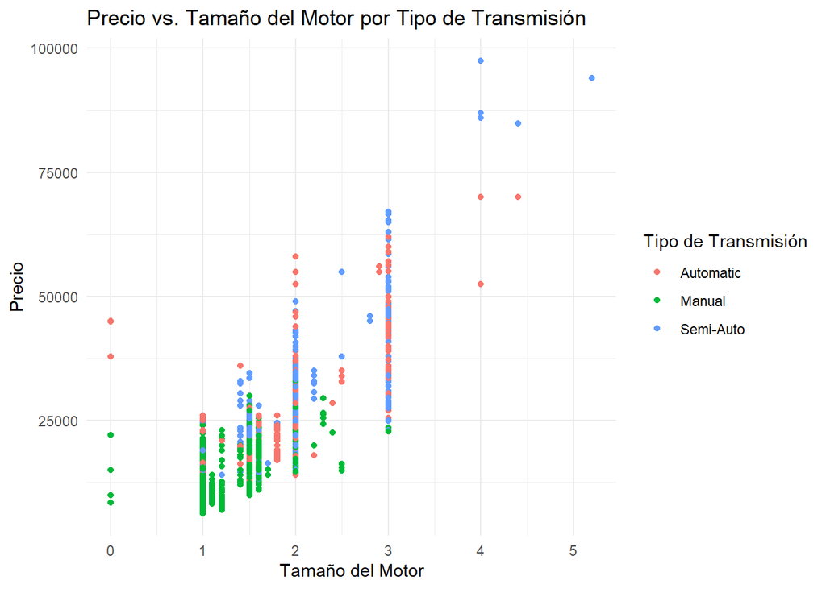

```r
ggplot(data, aes(x = engineSize, y = price, color = factor(transmission))) +
  geom_point() +
  labs(title = "Precio vs. Tamaño del Motor por Tipo de Transmisión",
       x = "Tamaño del Motor", y = "Precio", color = "Tipo de Transmisión") +
  theme_minimal()
```

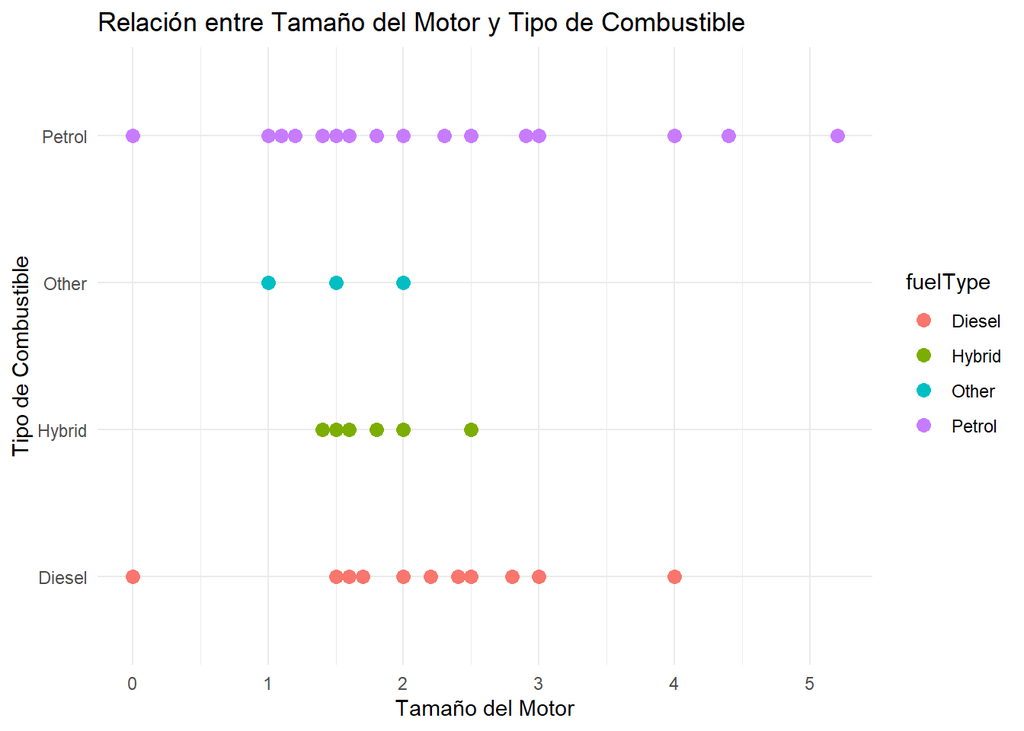

```r
#tipo de combustible con respecto al tamaño del motor
ggplot(data, aes(x = engineSize, y = factor(fuelType), color = fuelType)) +
  geom_point(size = 3) +
  labs(title = "Relación entre Tamaño del Motor y Tipo de Combustible",
       x = "Tamaño del Motor",
       y = "Tipo de Combustible") +
  theme_minimal()
```

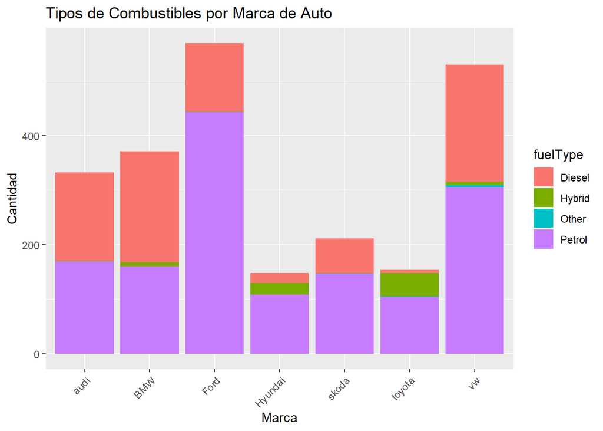

```r
#tipo de combustible por marca de auto
ggplot(data, aes(x = factor(Make), fill = fuelType)) +
  geom_bar(position = "stack") +
  labs(title = "Tipos de Combustibles por Marca de Auto", x = "Marca", y = "Cantidad") +
  theme(axis.text.x = element_text(angle = 45, hjust = 1))
```

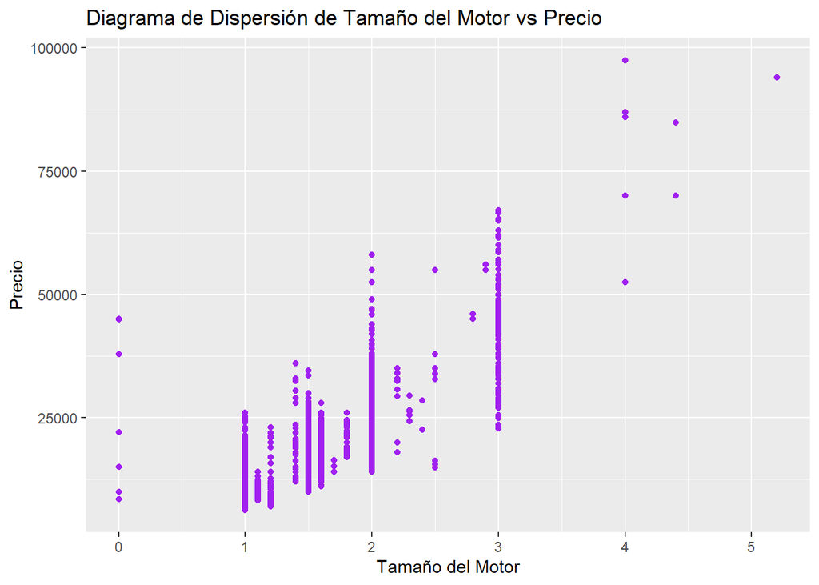

```r
#Gráfico de dispersión para la relación entre el tamaño del motor (engineSize) y el precio (price):
ggplot(data, aes(x = engineSize, y = price)) +
  geom_point(color = "purple") +
  labs(title = "Diagrama de Dispersión de Tamaño del Motor vs Precio", x = "Tamaño del Motor", y = "Precio")
```

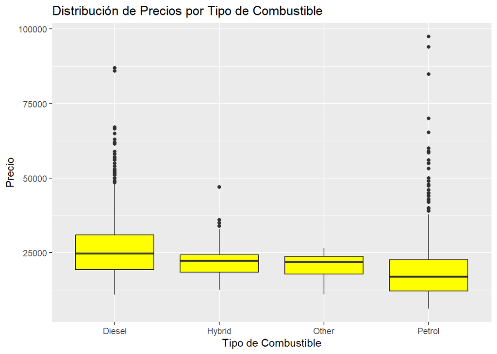

```r
#Boxplot para visualizar la distribución de precios (price) por tipo de combustible (fuelType):
ggplot(data, aes(x = fuelType, y = price)) +
  geom_boxplot(fill = "yellow") +
  labs(title = "Distribución de Precios por Tipo de Combustible", x = "Tipo de Combustible", y = "Precio")
```

**Hipotesis:**

```r
n<-length(data$price)

variedad_motores <- data %>%
  group_by(data$Make) %>%
  summarise(Variedad_Motores = n_distinct(data$engineSize))

# Ordenar por la variedad de motores en orden descendente
variedad_motores <- variedad_motores %>%
  arrange(desc(Variedad_Motores))

variedad_motores
```

```
## # A tibble: 7 × 2
##   `data$Make` Variedad_Motores
##   <chr>                  <int>
## 1 BMW                       20
## 2 Ford                      20
## 3 Hyundai                   20
## 4 audi                      20
## 5 skoda                     20
## 6 toyota                    20
## 7 vw                        20
```